# Investigating COVID-19 Death Rates

Esmma Almousa, Brenden Paddock, Richard Ren and Tanner Sterling

## Introduction

In the middle of a global pandemic there are several unanswered questions. How did we get here? When will this end? There are more quantitative questions: Do lockdowns work? Does better testing yield safer lives? Our question we analyzed: How are COVID-19 death rates different for different people? Though COVID-19 does not effect different race differently physically, there are likely to be many externalities that cause disparities between races.

## Background

Our first data set, titled **CA_Covid**, was collected from the California Health and Human Services Open data Portal located at https://data.chhs.ca.gov/. This dataset provides California’s state data and out of state data related to COVID-19 beginning from the date 2020-01-01 and ending date of 2021-03-29. This data set incorporates multiple variables, but the variables that were incorporated into our project from this include the following:

**Area**: This variable identifies whether the row in this dataset is identified from an area “Out of State”, “Unknown” or identifies the name of the California county if the data is from in state.  
**Cases**: This variable portrays the number of cases identified in this county.  
**Deaths**: This variable portrays the number of deaths identified in this county.

The first step we will take to clean this dataset is filter out any areas that are identified as “Unknown” or “Out of State” since we wish to focus on California county data only. Next, we plan to group this data by area and summarize the data by having cases equal to the sum of all cases for this county, and deaths equal to the sum of all deaths in this county. We will then create our own variable called **death_rate** which will be the quotient of **deaths**/**cases**.

Our second dataset, titled **County_Census_2017**, was collected from the United States Census Bureau located at https://www.census.gov/. This dataset provides data for multiple states and counties regarding the number of men, women, unemployed individuals, individuals in poverty, and number of individuals within specific races as well as the overall population of the county. The following variables were incorporated into our dataset:  
**State**: Represents the state which the data is from  
**County**: Represents the county which the data is from  
**Population**: Represents the total population of the county  
**Men**: Represents the number of men in the county  
**Women**: Represents the number of women in the county  
**Hispanic**: Represents the number of Hispanic individuals in the county  
**White**: Represents the number of White individuals in the county  
**Black**: Represents the number of Black individuals in the county  
**Native**: Represents the number of Native American individuals in the county  
**Asian**: Represents the number of Asian individuals in the county  
**Pacific**: Represents the number of Pacific Islander individuals in the county  
**Poverty**: Represents the number of individuals in poverty in the county  
**Unemployment**: Represents the number of unemployed individuals in the county

We plan to only filter out counties from the state of California since we are focused on analysis in this state. We will then convert our variables (excluding population) to percentages by dividing each variable by 100. We will then use full_join to join the two datasets together by county.

Another data set **covid19casesdemographics.csv** was also collected from the California Health and Human Services Open data Portal located at https://data.chhs.ca.gov/. In this data set, each row shows total number of cases at a specific date and its percent of CA population. We only obtained the values of those whose race is in this set: (American Indian or Alaska Native, Asian, Black, Latino, Multi-Race, Native Hawaiian and other Pacific Islander, White). We saved the latest values by slicing the nearest date. We got the total population of CA from the Census data set and times the percent of CA population of each race to figure out the exact number of each race in CA. We divided the number of COVID cases by the total number of that race to get an estimated value for getting COVID for every race. This data will be used to conduct a Likelihood Ratio Test for contracting COVID-19 among different races.

Our question of focus for this analysis will be: **How does the death rate of COVID-19 differ among different races and socioeconomic backgrounds?**

## Analysis

### Likelihood Ratio Test

- We want to consider a hypothesis test to see if the probabilities are not all the same for different racial groups. We write out the test like this:

$$H_0: p_1 = \ldots = p_7 \\
H_a: \text{not}~ p_1 = \ldots = p_7$$

- $p_1$ representing “American Indian or Alaska Native”, $p_2$ representing “Asian” etc.
- The null hypothesis is that all of the probabilities of getting COVID are the same for each racial group.
- The alternative hypothesis is that they are not all the same (at least one is different).

```
## # A tibble: 1 × 4
##     log_L0 log_L1     lrt     R
##      <dbl>  <dbl>   <dbl> <dbl>
## 1 -351051.  -50.3 702002.     0
```

- There are 7 different races in the data set, so degrees of freedom = 7 - 1 = 6.

```
## # A tibble: 1 × 5
##     log_L0 log_L1     lrt     R p_value
##      <dbl>  <dbl>   <dbl> <dbl>   <dbl>
## 1 -351051.  -50.3 702002.     0       0
```

- The p-value is 0. We reject the null hypothesis. We have evidence that the probability of getting COVID for people of different races are not the same.

### Different Races vs COVID-19 Death Rate, By County in California

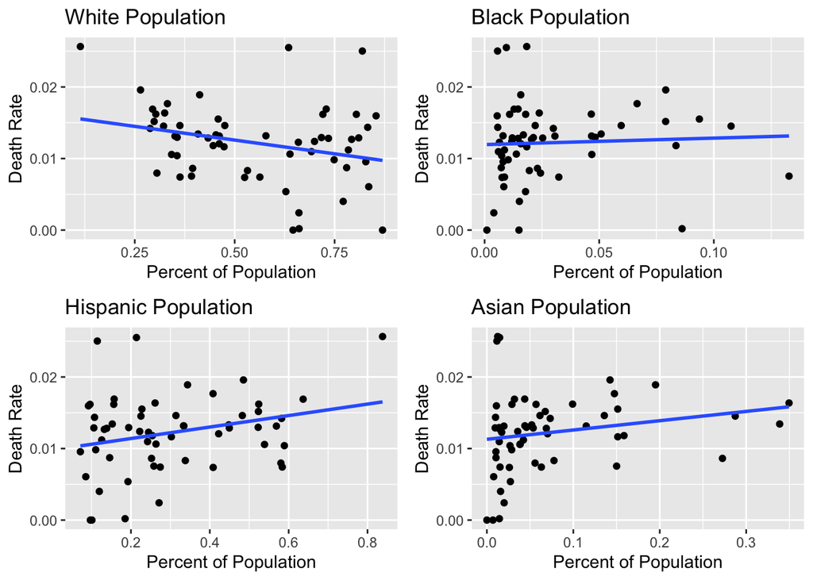

The first set of linear regression graphs show the relationship between the percent of population of the race specified and the Death Rate of COVID-19. These sets of graphs help us answer our question in finding how COVID affects different races for each county in California. There seems to be a negative, linear trend for COVID death rates as the percentage of the population being white in the county increases. The relationship for COVID death rates seems to rise slightly while the percentage of the county population being black rises. The bottom two sets of graphs show as the percentage of Hispanic and Asian population increases, so does the COVID Death Rate.

### Unemployment and Poverty Affect on COVID-19 Death Rate, with Race

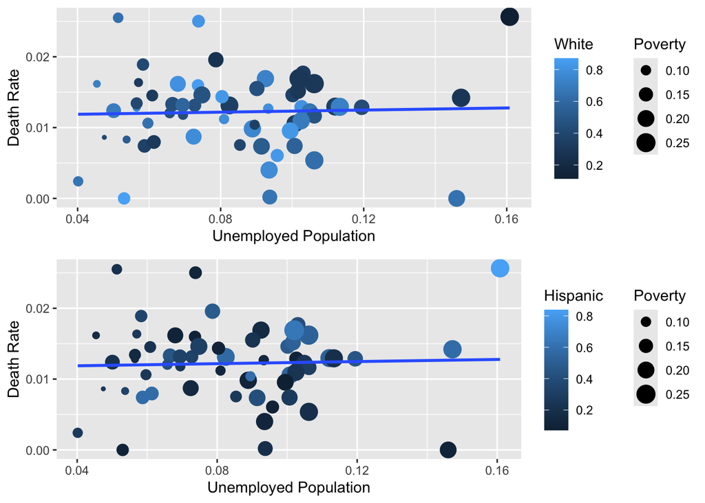

The second set of linear regression graphs show the relationship between unemployment rate and COVID-19 Death Rate. There is a slight increase in COVID-19 death rates as unemployment increases. The poverty percentage also increases as the unemployment rate increases, with a higher hispanic percentage of population being to the center and right. There is a high percentage of white population towards the lower ends of the unemployment rate as well.

## Interpretation

### Likelihood Ratio Test

- The likelihood ratio test was done in order to determine whether statistically significant that the chance of contracting COVID is the same for each race.
- Our statistic is $G = -2 (\ln L_0 - \ln L_1) = 2(\ln L_1 - \ln L_0)$.
- We compared our test statistic to a chi-square distribution with 6 degrees of freedom, since there are 7 difference races included in the data set. The p-value turns out to be exactly 0. We have evidence to conclude that race is an important factor which affects the chance of contracting COVID.

### Different Races vs COVID-19 Death Rate

- Four graphs were generated displaying race vs death rate. These graphs answer how different races can be affect by COVID-19.
- The graphs were all fit with a linear fit line which shows the trend of data. From this line we can tell that different races do face different COVID-19 rates.
- The graph of the White population shows a negative correlation with death rate, where as the graphs of Black, Hispanic and Asian population all show a positive correlation with death rate.
- We have determined that there is a difference in COVID-19 death rates between races, but there are still questions about what fuels this disparity.

## Conclusion

A different way to analyze our data is looking at an exponential model of our data instead of a linear model to infer if there is an exponential relationship between the variables instead. We would also be interested in creating box plots to demonstrate death rates for different races, in order to identify any significant outliers as well as quartiles within the data.

Our hypothesis test shows that the p-value is 0, meaning we can reject the null hypothesis since it is below .05, demonstrating that the probability of getting COVID-19 for people of different races are not the same. This raises other questions such as: is there significant evidence that the probability of getting COVID-19 is different among different ages?

However, it is important to recognize that we cannot come to a strict conclusion on our findings as it is important to recognize confounding factors that may have influenced the results. Factors such as the individual’s age, location, and current status in health could have played a role in the linear regression results. Future questions could also include, How does the death rate of covid-19 differ among different ages? It is important to remember that there could be many shortcomings in our analysis since other personal factors of each individual were not taken into consideration.